```python
import sys
sys.path.append("../")
from utils.null_analyzer import NullAnalyzer
import pandas as pd
import numpy as np
from utils.target_var_inspection import plot_kde, plot_barchart
from utils.target_var_inspection import plot_log_transformed_distr
from utils.neighborhood_cleaning import normalize_neigh_col
import statsmodels.api as sm
from statsmodels.stats.outliers_influence import variance_inflation_factor
import matplotlib.pyplot as plt
import seaborn as sns
```

# Demand Decomposition of Short Term Rentals in Lombardy

## Introduction

For decades, most of the accommodation available for tourists visiting a city was provided by specialized structures like hotels. In the past few years, companies like Airbnb completely changed this paradigm, allowing regular people to rent out their apartments to tourists.  
While this opportunity allowed many hosts to profit from their previously empty houses, it has also reshaped the neighborhood dynamics and composition of many cities, such as Milan, Bergamo and others, causing traditional businesses to disappear, while tourist oriented businesses proliferated.  
While the topic itself can be seen as controversial, we find the underlying dynamics that power it very interesting, and we aim to explore them with this project.

## Data Loading

Before starting the data exploration, we report some of the known limitations of the dataset, also highlighted on the **Inside Airbnb** website.

- When building the dataset, it was not possible to differentiate between a "booked" listing and an unavailable (e.g. blocked by the host) listing. The authors therefore simply reported the availability rate, intended as the number of nights in which the room can be booked.
- There is no historic data about past occupancy and past revenue generated, therefore the authors use some proxy to provide an estimate based on the number of reviews received by the listing.

```python
df_mi = pd.read_csv("../../data/listings_milan.csv")
df_bg = pd.read_csv("../../data/listings_bergamo.csv")

df_mi.head()
```

|  | id | listing_url | scrape_id | last_scraped | source | name | description | neighborhood_overview | picture_url | host_id | ... | review_scores_communication | review_scores_location | review_scores_value | license | instant_bookable | calculated_host_listings_count | calculated_host_listings_count_entire_homes | calculated_host_listings_count_private_rooms | calculated_host_listings_count_shared_rooms | reviews_per_month |
| --- | --- | --- | --- | --- | --- | --- | --- | --- | --- | --- | --- | --- | --- | --- | --- | --- | --- | --- | --- | --- | --- |
| 0 | 23986 | https://www.airbnb.com/rooms/23986 | 20250922033939 | 2025-09-24 | city scrape | " Characteristic Milanese flat" | I look forward to welcoming you in my flat; it... | NaN | https://a0.muscache.com/pictures/623d63f8-56cf... | 95941 | ... | 4.73 | 4.69 | 4.46 | NaN | f | 1 | 1 | 0 | 0 | 0.16 |
| 1 | 40470 | https://www.airbnb.com/rooms/40470 | 20250922033939 | 2025-09-24 | previous scrape | Giacinto Cosy & clean flat near MM1 | NaN | NaN | https://a0.muscache.com/pictures/891684/01c17b... | 174203 | ... | 4.88 | 4.45 | 4.52 | IT015146C2YDCLSU8G | f | 2 | 2 | 0 | 0 | 0.24 |
| 2 | 46536 | https://www.airbnb.com/rooms/46536 | 20250922033939 | 2025-09-24 | city scrape | Nico & Cinzia's Pink Suite! | Over the international fair in April we rent f... | Flat It's located in north side of milan, jus... | https://a0.muscache.com/pictures/4eb8e0f5-e17b... | 138683 | ... | 4.92 | 4.34 | 4.58 | IT015209C2BBKGCMT7 | f | 1 | 1 | 0 | 0 | 0.23 |
| 3 | 84741 | https://www.airbnb.com/rooms/84741 | 20250922033939 | 2025-09-24 | city scrape | Nice room with private bathroom | Independent room with private bathroom.<br />C... | It may seem a peripheral zone and bare, but ju... | https://a0.muscache.com/pictures/0b34089b-4d58... | 443989 | ... | 4.88 | 4.18 | 4.64 | I applied for a CIN, but haven’t received it yet | f | 3 | 1 | 2 | 0 | 3.94 |
| 4 | 88130 | https://www.airbnb.com/rooms/88130 | 20250922033939 | 2025-09-24 | city scrape | Great comfortable & quite APT. x 4 people! | Our bright and comfortable apartment for 3+ 1 ... | NaN | https://a0.muscache.com/pictures/606790/408e10... | 481475 | ... | 5.00 | 4.43 | 4.71 | NaN | f | 1 | 1 | 0 | 0 | 0.04 |

5 rows × 79 columns

```python
df_mi.info()
```

```
<class 'pandas.DataFrame'>
RangeIndex: 22933 entries, 0 to 22932
Data columns (total 79 columns):
 #   Column                                        Non-Null Count  Dtype
---  ------                                        --------------  -----
 0   id                                            22933 non-null  int64
 1   listing_url                                   22933 non-null  str
 2   scrape_id                                     22933 non-null  int64
 3   last_scraped                                  22933 non-null  str
 4   source                                        22933 non-null  str
 5   name                                          22933 non-null  str
 6   description                                   22481 non-null  str
 7   neighborhood_overview                         10646 non-null  str
 8   picture_url                                   22933 non-null  str
 9   host_id                                       22933 non-null  int64
```

[output cut: 71 more lines]

```python
df_bg.info()
```

```
<class 'pandas.DataFrame'>
RangeIndex: 3835 entries, 0 to 3834
Data columns (total 79 columns):
 #   Column                                        Non-Null Count  Dtype
---  ------                                        --------------  -----
 0   id                                            3835 non-null   int64
 1   listing_url                                   3835 non-null   str
 2   scrape_id                                     3835 non-null   int64
 3   last_scraped                                  3835 non-null   str
 4   source                                        3835 non-null   str
 5   name                                          3835 non-null   str
 6   description                                   3744 non-null   str
 7   neighborhood_overview                         1520 non-null   str
 8   picture_url                                   3835 non-null   str
 9   host_id                                       3835 non-null   int64
```

[output cut: 71 more lines]

We notice that both dfs have the same colums, and that the Milan listings are 6x more than the Bergamo ones.  
Additionally, while many columns have no null values, some crucial ones like **price** have null values that will need to be addressed.

We start by joining the two dfs together, adding a column that identifies in which city is each listing.

```python
## Adding an unambiguous first column to avoid collisions later
df_mi["unique_id"] = df_mi["id"].astype(str) + "_mi"
df_mi["city"] = "MI"
df_bg["unique_id"] = df_bg["id"].astype(str) + "_bg"
df_bg["city"] = "BG"


n_rows_mi = df_mi.shape[0]
n_rows_bg = df_bg.shape[0]

column_order = ["unique_id", "city"] + [col for col in df_mi.columns if col not in ("unique_id", "city")]
df_mi = df_mi[column_order]
df_bg = df_bg[column_order]

# Merging the dfs
df = pd.concat([df_mi, df_bg], axis=0, ignore_index=True)
assert n_rows_bg + n_rows_mi == df.shape[0] # Verifying all rows are preserved
```

## Column Selection

```python
necessary_cols = [
    "unique_id",
    "city",
    "host_since",
    "host_response_rate",
    "host_response_time",
    "minimum_nights",
    "number_of_reviews_l30d",
    "number_of_reviews_ly",
    "first_review",
    "last_review",
    "availability_30",
    "availability_60",
    "availability_90",
    "availability_365",
    "accommodates",
    "host_is_superhost",
    "neighbourhood_cleansed",
    "room_type",
    "price"]

df = df[necessary_cols]
```

We verify the integrity of all the relevant columns of the df.

```python
## Running check on NULL entries
null_analyzer = NullAnalyzer(threshold=5, stratify_col="city")

null_analyzer.check_nulls_globally(df=df)
null_analyzer.check_nulls_strat(df=df, delta_threshold=5)
```

```
OVERALL NULL PCT (Threshold > 5.00%)
	Column: host_response_rate             | Global Nulls: 15.58%
	Column: host_response_time             | Global Nulls: 15.58%
	Column: first_review                   | Global Nulls: 14.70%
	Column: last_review                    | Global Nulls: 14.70%
	Column: price                          | Global Nulls: 10.12%

Difference in NULL percentage between MI and BG
	MI and BG exhibit the same proportion of NULL values across all columns.
```

We fill the nulls in all columns except the price one. We also add flags to record which hosts never had reviews or were never contacted.

```python
fill_values = {
    "host_since": "2000-01-01",
    "host_response_rate": "0%",
    "host_response_time": "unknown",
    "minimum_nights": 1,
    "maximum_nights": 365,
    "number_of_reviews_l30d": 0,
    "number_of_reviews_ly": 0,
    "first_review": "2000-01-01",
    "last_review": "2000-01-01",
    "availability_30": 0,
    "availability_60": 0,
    "availability_90": 0,
    "availability_365": 0,
    "accommodates": 1,
    "host_is_superhost": "f",
    "neighbourhood_cleansed": "unknown",
    "room_type": "unknown",
}


df["has_host_been_contacted"] = df["host_response_rate"].isna()
df["host_never_had_reviews"] = df["first_review"].isna()
df["host_without_join_date"] = df["host_since"].isna()

n_before = df.shape[0]
df = df.fillna(value=fill_values).dropna()
n_after = df.shape[0]
print(f"Rows before: {n_before}, rows after: {n_after}, dropped rows: {(n_before - n_after)/n_before:.2%}")
```

```
Rows before: 26768, rows after: 24060, dropped rows: 10.12%
```

### Scope Definition

In this subsection, we filter out listings that do not fall within the scope of this project. For instance, we will investigate the following characteristics:

- how old/new a listing is
- whether the listing is long or short term

```python
snapshot_date = pd.to_datetime(df["last_scraped"].iloc[0] if "last_scraped" in df.columns else "2025-09-27")
df["host_age_days"] = (snapshot_date - pd.to_datetime(df["host_since"], errors="coerce")).dt.days
```

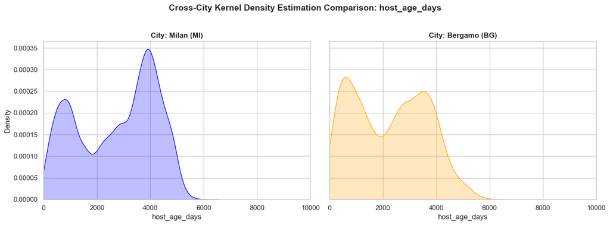

```python
plot_kde(df[~df["host_without_join_date"]], target_column="host_age_days", city_column="city", rng=(0, 10000))
```

We clearly see that most hosts joined the platform more than 1y ago. Since we do not have the listing initial date available, we use the host join date as proxy for listing insertiond date, and remove all listings whose host joined the platform less than one year ago.  
We perform this action to ensure that listings have been operational for a sufficient time and do not benefit from initial-only effects.  
We remark that the choice of the proxy is very conservative, and leaves in the df all the listings that are new, but belong to a host that had previous listings.

```python
n_before = df.shape[0]
df = df[df["host_age_days"] >= 365]
n_after = df.shape[0]
print(f"Filtered out {(n_before - n_after)/n_before:.2%} listings with host age < 1 year")

# Building occupancy features
occupancy_windows = [30, 60, 90, 365]
for window in occupancy_windows:
    df[f"occupancy_{window}"] = 1 - (df[f"availability_{window}"] / window)
```

```
Filtered out 5.76% listings with host age < 1 year
```

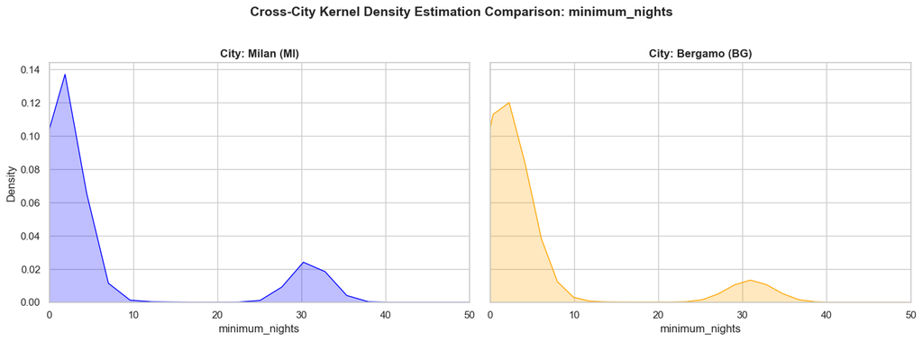

```python
plot_kde(df, target_column="minimum_nights", city_column="city", rng=(0, 50))
```

The minimum nights variable exhibits a clear bimodal distribution, with a peak around 2/3 days likely indicating short term renters, and another one around 30 days likely indicating long term renters.  
For the purpose of this project, we can remove the long term renters.

```python
# Restricting the scope to short term rentals
n_before = df.shape[0]
df = df[df["minimum_nights"] < 15]
n_after = df.shape[0]

print(f"Filtered out {(n_before - n_after)/n_before:.2%} listings with minimum_nights >= 15")
print(f"Retained {n_after} listings with minimum_nights < 15")
```

```
Filtered out 14.92% listings with minimum_nights >= 15
Retained 19291 listings with minimum_nights < 15
```

## Analysis of Occupancy Variable (Dependent Variable)

The main objective of the analysis is to estimate the demand of listings through multivariate regression. We use the occupancy rate in the next 90 days as proxy for the demand.  
The reason for this choice is that we find that it is a sufficiently long period of time to average out noise, while it is not long enough to cause most listings to have a very low occupancy rate.  
We have that $Occupancy \in [0, 1]$, but we need a well behaved distribution to perform an accurate regression. In this subsection, we inspect the distribution and perform the necessary cleaning.

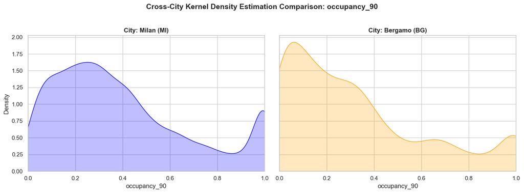

```python
## VERIFYING WHETHER MILAN AND BERGAMO TARGET VARIABLES ARE DISTRIBUTED DIFFERENTLY
plot_kde(df, target_column="occupancy_90", city_column="city", rng=(0, 1))
```

We notice that both Milan and Bergamo have awkward distributions, with peaks around $Occupancy = 1$, signalling an unusually high number of fully booked listings  
We also identify slight peaks around $Occupancy = 0.33$ and $Occupancy = 0.66$, potentially signalling peaks in listings that are fully booked in the 30 or 60 days.  
As described at the beginning, our occupancy metric is computed from the author's availability metric, which only computes the bookable nights, without making a distinction as to why a night is not bookable.

We hypothesize that there are two underlying phenomena that are simultaneusly distorting the data:

- Listings Blocked by Hosts
- Listings not managed by hosts  
  Blocked listings might happen when hosts set them as unavailable for the upcoming 90 days. The scraping identifies these bookings are occupied because the room is indeed **not available**, but clearly these listings are not meaningful for the analysis.  
  On the other hand, listings that are not managed are listings that never receive any traffic and that likely did not attract any client in a long time, potentially also because of bad management on the host's side.

### Data Refinement

In order to remove all the listings which are 100% occupied because they are blocked by the hosts, we must find distinctive characteristics that separate true best sellers from blocked entries.  
We start by inspecting the host response rate and time, under the assumption that true top sellers will have hosts that have top performance in these two fields.

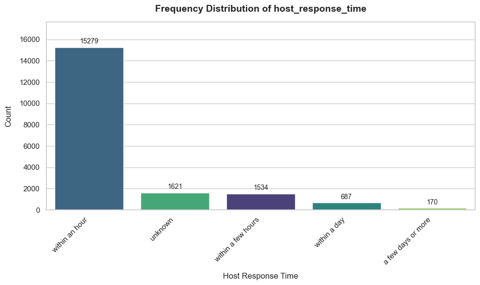

```python
plot_barchart(df, category_col="host_response_time")
```

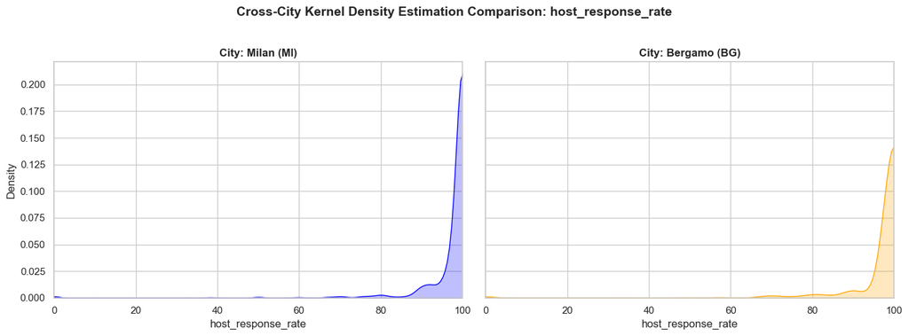

```python
df["host_response_rate"] = df["host_response_rate"].astype(str).str.rstrip("%")

df["host_response_rate"] = pd.to_numeric(
    df["host_response_rate"], errors="coerce"
).astype("Int64")

plot_kde(df[~df["has_host_been_contacted"]], target_column="host_response_rate", rng=(0, 100))
```

The overwhelming majority of hosts in both cities responds "within an hour" and has response rate above 90%. It is safe to assume that true top sellers will have hosts that respond within an hour and with response rate above 90%.

```python
df["is_host_inactive"] = (df["host_response_rate"] < 90) | (df["host_response_time"] != "within an hour")
```

```python
# Constructing features to capture host inactivity and blocked listings

df["last_review_dt"] = pd.to_datetime(df["last_review"], errors="coerce")
df["first_review_dt"] = pd.to_datetime(df["first_review"], errors="coerce")

df["reviews_per_year"] = pd.to_numeric(df["number_of_reviews_ly"], errors="coerce")
df["availability_365"] = pd.to_numeric(df["availability_365"], errors="coerce")

df["is_host_inactive"] = df["is_host_inactive"].astype(bool)
df["host_never_had_reviews"] = df["host_never_had_reviews"].astype(bool)

df["occupancy_90"] = pd.to_numeric(df["occupancy_90"], errors="coerce")
df["occupancy_60"] = pd.to_numeric(df["occupancy_60"], errors="coerce")
df["occupancy_30"] = pd.to_numeric(df["occupancy_30"], errors="coerce")
```

We use the following thresholds to define "high occupancy":

- For the 90 days, a 90% occupancy is considered high
- For the next 60 days, a 90% occupancy is considered high
- For the next 30 days, a 95% occupancy is considered high

Additionally, we consider as very unlikely that a true top-selling listing had few reviews in the past year.
We use the following formula to compute a very conservative estimate of the number of reviews a top-selling listing must have received, also accounting for seasonality and potential closures. $$ \frac{time\_window * occupancy\_rate}{avg\_stay\_duration} * review\_rate $$ Where the fraction computes the expected number of guests the listing had in the 90 days time window last year, and the review rate maps that number into the expected number of reviews.
This formula is very conservative in the sense that assumes that the listing last year was live for at least the time window for which is highly booked now, and estimates the number of reviews it would have obtained last year.
Using a the very conservative $review\_rate = 50\%$ and $avg\_stay\_duration = 4 nights$, we obtain the following results:

- 10 reviews for 90 day period
- 7 reviews for 60 day period
- 4 reviews for 30 day period

```python
high_occupancy_90 = df["occupancy_90"] > 0.90
high_occupancy_60 = df["occupancy_60"] > 0.90
high_occupancy_30 = df["occupancy_30"] > 0.95


block_conditions = [
    high_occupancy_90,
    high_occupancy_60,
    high_occupancy_30
]

review_floor_choices = [10, 7, 4]

df["required_review_floor"] = np.select(block_conditions, review_floor_choices, default=0)
```

We consider a listing blocked if the listing is high demand and one of the following conditions holds:

- **The host has not had a single review in the last 30 days**. We find it unlikely that a listing that had no review for a month is not fully booked
- **The host had less reviews than the threshold set before**. We find it unlikely that a fully booked listing had very little reviews in the past year.
- **The host has 0% availability for the whole year**. We find it unlikely that any listing is fully booked one year in advance.
- **The host is either inactive or never had any review**. We find it unlikely that a low quality host can have a fully booked listing.

```python
cond_review_stale = (snapshot_date - df["last_review_dt"]).dt.days > 30       # hasn't been reviewed in a month

cond_low_momentum = (df["reviews_per_year"] < df["required_review_floor"])
cond_calendar_dead = df["availability_365"] == 0
cond_host_dead = (df["is_host_inactive"] | df["host_never_had_reviews"]) == True

any_trigger_tripped = (
    cond_review_stale |
    cond_low_momentum |
    cond_calendar_dead |
    cond_host_dead
)

df["block_90"] = high_occupancy_90 & any_trigger_tripped
df["block_60"] = high_occupancy_60 & any_trigger_tripped & ~high_occupancy_90
df["block_30"] = high_occupancy_30 & any_trigger_tripped & ~high_occupancy_60 & ~high_occupancy_90

df["is_blocked"] = df["block_90"] | df["block_60"] | df["block_30"]
```

```python
n_before = df.shape[0]
df = df[~df["is_blocked"]]
n_after = df.shape[0]

print(f"Filtered out {(n_before - n_after)/n_before:.2%} listings flagged as blocked")
print(f"Retained {n_after} listings not flagged as blocked")
```

```
Filtered out 14.26% listings flagged as blocked
Retained 16541 listings not flagged as blocked
```

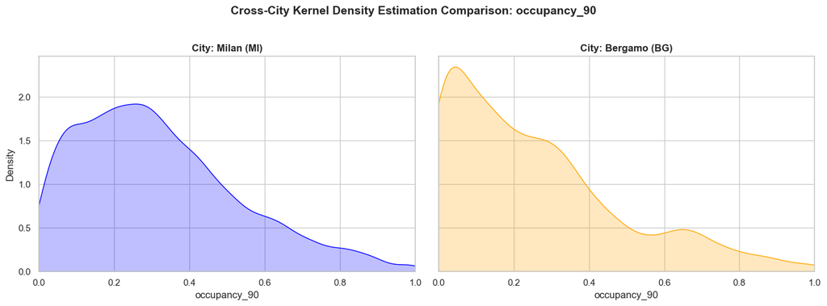

```python
plot_kde(df, target_column="occupancy_90", city_column="city", rng=(0, 1))
```

We find that the distributions are now much smoother, and there is no bump around 100% occupancy, signalling that indeed many listings were blocked by hosts.

We now tackle the issue of dead listings, which are likely not managed.  
We choose to remove listings that have 0 nights booked in the next 90 days and that had 0 reviews in the past 180 days.

```python
cond_listing_dead = ((snapshot_date - df["last_review_dt"]).dt.days > 180) & (df["occupancy_90"] == 0)
cond_listing_not_managed = (df["is_host_inactive"] & (df["occupancy_90"] == 0))
n_before = df.shape[0]
df = df[~(cond_listing_dead | cond_listing_not_managed)]
n_after = df.shape[0]
print(f"Filtered out {(n_before - n_after)/n_before:.2%} listings flagged as potentially dead")
print(f"Retained {n_after} listings not flagged as potentially dead")
```

```
Filtered out 1.32% listings flagged as potentially dead
Retained 16322 listings not flagged as potentially dead
```

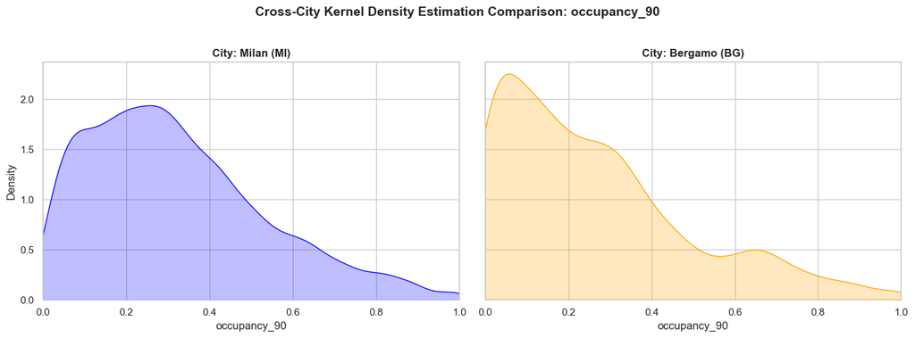

```python
plot_kde(df, target_column="occupancy_90", city_column="city", rng=(0, 1))
```

## Log-Transformation of Target Variable

As clarified in the introduction, we are interested in estimating the price elasticity of demand. In order to do so, we will select as independent variable $\log(Price)$, and as dependent variable $\log(Occupancy)$, so that the regression coefficient will represent elasticity.  
For this reason, we also inspect the distribution of the log transformed occupancy.

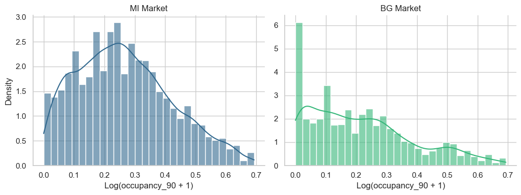

```python
plot_log_transformed_distr(df, variable_col="occupancy_90", city_col="city")
```

While Milan exhibits a nice distribution, Bergamo is dominated by values that are very close to 0, signalling a fundamental difference between the two markets.  
While the Milan market is very mature and highly booked year-round, Bergamo shows a very high number of not booked listings which were not eliminated by the filters, and which are likely seasonal listings that are popular during summer and are abandoned during winter, when the turist influx stops.

## Price Analysis

As mentioned above, we will use $\log(Price)$ in the regression, therefore we inspect its distribution

```python
df["price"] = df["price"].str.replace("$", "", regex=False)
df["price"] = df["price"].str.replace(",", "", regex=False)
df["price"] = df["price"].astype(float).astype(int)
```

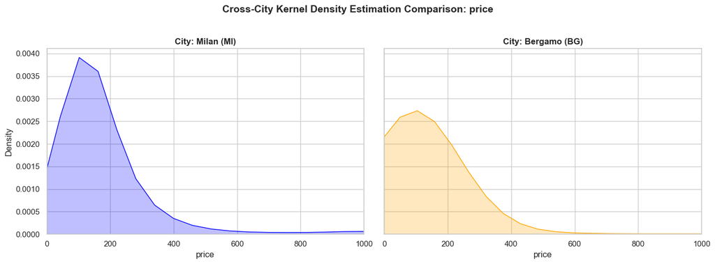

```python
plot_kde(df, target_column="price", city_column="city", rng=(0, 1000))
```

As well as its log-transformed distribution

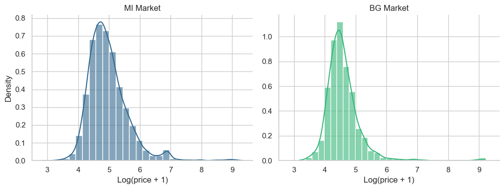

```python
plot_log_transformed_distr(df, variable_col="price", city_col="city")
```

The log-transformed price distributions are very close to a normal.

## Neighborhood Analysis

We plan to use the different neighborhoods as categorical variables in the regression, to inspect their respective impacts on the baseline demand.  
In this subsection, we inspect and clean the variable.

```python
print("Most Popular Neighbourhoods (MI):")
print(df["neighbourhood_cleansed"][df["city"] == "MI"].value_counts().head(10))

print("\nLeast Popular Neighbourhoods (MI):")
print(df["neighbourhood_cleansed"][df["city"] == "MI"].value_counts().tail(10))

print("Most Popular Neighbourhoods (BG):")
print(df["neighbourhood_cleansed"][df["city"] == "BG"].value_counts().head(10))

print("\nLeast Popular Neighbourhoods (BG):")
print(df["neighbourhood_cleansed"][df["city"] == "BG"].value_counts().tail(10))
```

```
Most Popular Neighbourhoods (MI):
neighbourhood_cleansed
BUENOS AIRES - VENEZIA    1168
DUOMO                     1166
CENTRALE                   680
SARPI                      633
BRERA                      619
LORETO                     554
NAVIGLI                    535
TICINESE                   512
ISOLA                      451
XXII MARZO                 378
Name: count, dtype: int64

Least Popular Neighbourhoods (MI):
neighbourhood_cleansed
FIGINO                  4
STEPHENSON              3
CANTALUPA               3
PARCO DEI NAVIGLI       2
PARCO DELLE ABBAZIE     2
PARCO NORD              1
PARCO BOSCO IN CITT    1
CHIARAVALLE             1
PARCO AGRICOLO SUD      1
SACCO                   1
Name: count, dtype: int64
Most Popular Neighbourhoods (BG):
neighbourhood_cleansed
Bergamo                 1115
Riva di Solto             85
Lovere                    64
Parzanica                 47
Seriate                   45
Solto Collina             39
Clusone                   38
Predore                   33
Sarnico                   32
San Pellegrino Terme      26
Name: count, dtype: int64

Least Popular Neighbourhoods (BG):
neighbourhood_cleansed
Lurano               1
Peia                 1
Parre                1
Telgate              1
Fiorano al Serio     1
San Paolo d'Argon    1
Gandino              1
Arzago d'Adda        1
Sedrina              1
Gaverina Terme       1
Name: count, dtype: int64
```

We see that most of the neighborhoods are very poorly populated, therefore we choose to group them in the following way:

- For Bergamo, if the neighborhood is "Bergamo" (i.e. the City), then call it "Bergamo_City", otherwise call it "Bergamo_Province"
- For Milan, retain only neighborhoods with more than 100 listins, and aggregate the others into "Other_Milan"

```python
df = normalize_neigh_col(df, threshold=100)
```

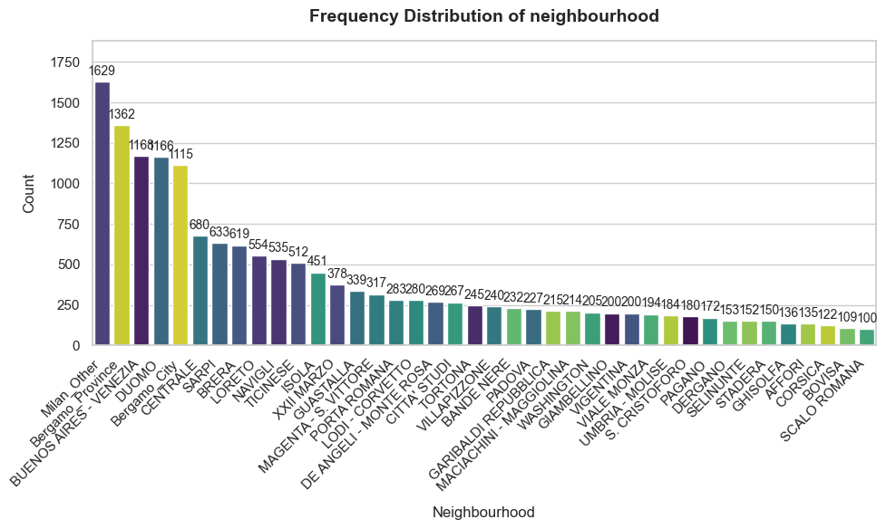

```python
plot_barchart(df, category_col="neighbourhood")
```

## Room Type Analysis

We also want to use the Room Type as categorical variable in the regression, therefore we inspect it.

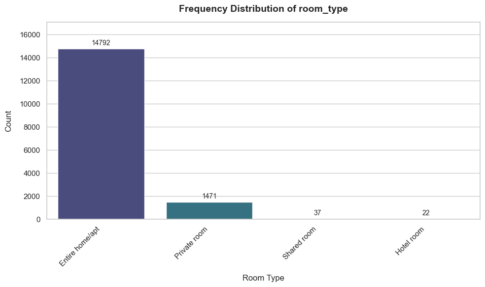

```python
plot_barchart(df, category_col="room_type")
```

Since "Shared room" and "Hotel room" have less than 1% of listings, we simply drop these rows and will verify how much renting a room modifies demand with respect to an entire home/apartment.

```python
df = df[df["room_type"].isin(["Entire home/apt", "Private room"])]
```

## Accommodates Analysis

Another interesting variable we will use in the regression is the number of guests a listing can accommodate.

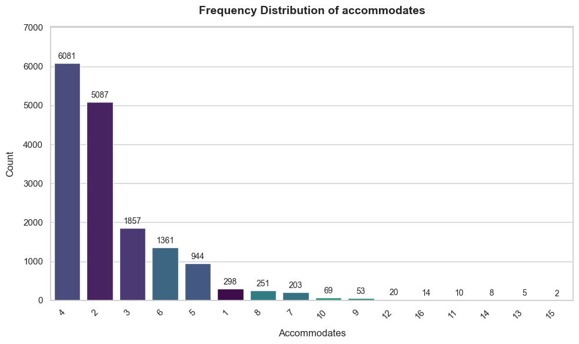

```python
plot_barchart(df, category_col="accommodates")
```

```python
print(df["accommodates"].value_counts(normalize=True).sort_index().cumsum())
```

```
accommodates
1     0.018324
2     0.331120
3     0.445305
4     0.819222
5     0.877267
6     0.960954
7     0.973437
8     0.988870
9     0.992129
10    0.996372
11    0.996987
12    0.998217
13    0.998524
14    0.999016
15    0.999139
16    1.000000
Name: proportion, dtype: float64
```

Listings which can accommodate 8 people or less cover more than 98% of the total listings. Since we are interested in the core short term rental market, which is mostly made of one-family rooms/houses, we can safely drop the listings which host more than 8 people.

```python
df = df[df["accommodates"] <= 8]
```

# Superhost Analysis

Since the dataset had no feature that directly mapped to "being a good host", we use the superhost indication of a host as proxy for their professionality.

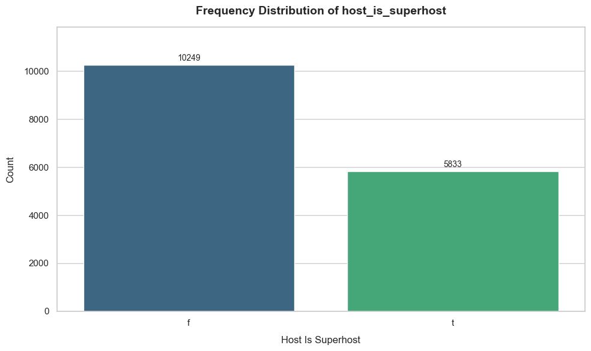

```python
plot_barchart(df, category_col="host_is_superhost")
```

The two categories are already well represented, so no further action is needed

# Model Fitting

## Data Transformation

```python
df = df.reset_index(drop=True)

# Creating Log transformed variables
df["occupancy_adj"] = np.clip(df["occupancy_90"], 0.001, 1.0) # to ensure no 0 values for log transformation
df["log_occupancy"] = np.log(df["occupancy_adj"])
df["price_adj"] = np.clip(df["price"], 1, None)
df["log_price"] = np.log(df["price_adj"])

# Creating binary variable for superhost status
df["is_superhost"] = (df["host_is_superhost"] == "t").astype(int)

room_type_dummies = pd.get_dummies(df["room_type"], prefix="room", drop_first=True, dtype=int)
neighbourhood_dummies = pd.get_dummies(df["neighbourhood"], prefix="neigh", drop_first=True, dtype=int)

X = df[["log_price", "accommodates", "is_superhost"]].join([room_type_dummies, neighbourhood_dummies])

room_categories = sorted(df["room_type"].unique())
geo_categories = sorted(df["neighbourhood"].unique())

print(f"Room Type that consistutes the baseline: {room_categories[0]}")
print(f"Neighborhood that constitutes the baseline: {geo_categories[0]}")
```

```
Room Type that consistutes the baseline: Entire home/apt
Neighborhood that constitutes the baseline: AFFORI
```

## Model Definition

```python
# Adding intercept term for regression
X = sm.add_constant(X)
Y = df["log_occupancy"]
```

```python
# We use robust standard errors (HC3) to account for potential heteroskedasticity in the residuals (especially for Bergamo)
model = sm.OLS(Y, X).fit(cov_type="HC3")
print(model.summary())
```

```
                            OLS Regression Results
==============================================================================
Dep. Variable:          log_occupancy   R-squared:                       0.125
Model:                            OLS   Adj. R-squared:                  0.123
Method:                 Least Squares   F-statistic:                     30.55
Date:                Mon, 08 Jun 2026   Prob (F-statistic):          6.85e-237
Time:                        00:32:31   Log-Likelihood:                -22682.
No. Observations:               16082   AIC:                         4.545e+04
Df Residuals:                   16038   BIC:                         4.579e+04
Df Model:                          43
Covariance Type:                  HC3
=================================================================================================
                                    coef    std err          z      P>|z|      [0.025      0.975]
-------------------------------------------------------------------------------------------------
const                            -0.0387      0.123     -0.315      0.753      -0.279       0.202
log_price                        -0.3634      0.021    -17.324      0.000      -0.404      -0.322
accommodates                      0.0727      0.006     11.700      0.000       0.061       0.085
is_superhost                      0.2152      0.016     13.763      0.000       0.185       0.246
room_Private room                -0.1669      0.032     -5.156      0.000      -0.230      -0.103
neigh_BANDE NERE                 -0.1022      0.112     -0.910      0.363      -0.322       0.118
neigh_BOVISA                     -0.0570      0.137     -0.417      0.677      -0.325       0.211
neigh_BRERA                       0.3951      0.096      4.133      0.000       0.208       0.582
neigh_BUENOS AIRES - VENEZIA      0.1555      0.092      1.686      0.092      -0.025       0.336
neigh_Bergamo_City               -0.0655      0.092     -0.715      0.475      -0.245       0.114
neigh_Bergamo_Province           -1.0385      0.099    -10.468      0.000      -1.233      -0.844
neigh_CENTRALE                    0.2691      0.094      2.857      0.004       0.084       0.454
neigh_CITTA' STUDI               -0.0584      0.105     -0.558      0.577      -0.263       0.147
neigh_CORSICA                    -0.2554      0.123     -2.076      0.038      -0.497      -0.014
neigh_DE ANGELI - MONTE ROSA      0.0471      0.107      0.441      0.659      -0.162       0.257
neigh_DERGANO                    -0.3823      0.124     -3.073      0.002      -0.626      -0.139
neigh_DUOMO                       0.5500      0.094      5.880      0.000       0.367       0.733
neigh_GARIBALDI REPUBBLICA        0.1147      0.110      1.042      0.298      -0.101       0.331
neigh_GHISOLFA                   -0.1029      0.122     -0.847      0.397      -0.341       0.135
neigh_GIAMBELLINO                -0.0591      0.106     -0.558      0.577      -0.267       0.149
neigh_GUASTALLA                   0.2963      0.101      2.938      0.003       0.099       0.494
neigh_ISOLA                      -0.0341      0.101     -0.337      0.736      -0.233       0.164
neigh_LODI - CORVETTO            -0.2349      0.108     -2.172      0.030      -0.447      -0.023
neigh_LORETO                      0.0030      0.098      0.030      0.976      -0.189       0.194
neigh_MACIACHINI - MAGGIOLINA    -0.1387      0.118     -1.174      0.240      -0.370       0.093
neigh_MAGENTA - S. VITTORE        0.2336      0.100      2.324      0.020       0.037       0.431
```

[output cut: 12 more lines]

```
neigh_UMBRIA - MOLISE             0.0353      0.111      0.317      0.751      -0.183       0.253
neigh_VIALE MONZA                -0.1195      0.111     -1.074      0.283      -0.337       0.099
neigh_VIGENTINA                   0.2267      0.104      2.174      0.030       0.022       0.431
neigh_VILLAPIZZONE               -0.2684      0.112     -2.405      0.016      -0.487      -0.050
neigh_WASHINGTON                  0.0520      0.105      0.496      0.620      -0.153       0.257
neigh_XXII MARZO                  0.1645      0.099      1.663      0.096      -0.029       0.358
==============================================================================
Omnibus:                     4499.147   Durbin-Watson:                   1.929
Prob(Omnibus):                  0.000   Jarque-Bera (JB):            16524.579
Skew:                          -1.372   Prob(JB):                         0.00
Kurtosis:                       7.139   Cond. No.                         435.
==============================================================================

Notes:
[1] Standard Errors are heteroscedasticity robust (HC3)
```

## Check of Regression Assumptions

### Multicollinearity

To verify that no multicollinearity is present, we compute the Variance Inflation Factor. In general, there is multicollinearity if a variable has VIF value that is 5 or higher.

```python
vif_data = pd.DataFrame({
    "X": X.columns,
    "VIF": [variance_inflation_factor(X.values, i) for i in range(X.shape[1])]
})
```

```python
print(vif_data[vif_data["VIF"]>5].sort_values(by="VIF", ascending=False).round(2))
```

```
                               X     VIF
0                          const  188.74
26             neigh_Milan_Other   11.76
10        neigh_Bergamo_Province   10.02
16                   neigh_DUOMO    9.14
8   neigh_BUENOS AIRES - VENEZIA    8.95
9             neigh_Bergamo_City    8.46
11                neigh_CENTRALE    5.75
32                   neigh_SARPI    5.50
7                    neigh_BRERA    5.45
```

Since only categorical variables have VIF > 5, we can consider the multicollinearity assumption satisfied.

### Linearity

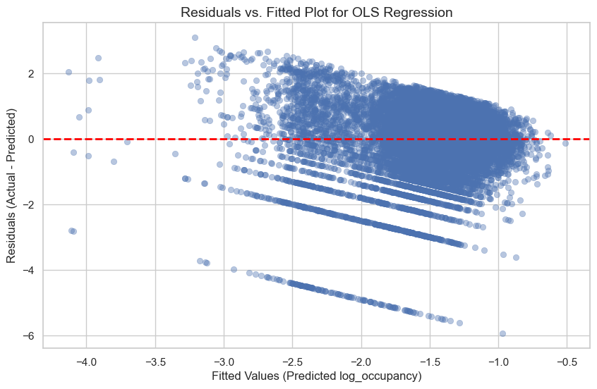

```python
fitted_values = model.fittedvalues
residuals = model.resid

plt.figure(figsize=(10, 6))
sns.scatterplot(x=fitted_values, y=residuals, alpha=0.4, edgecolor=None)

plt.axhline(y=0, color='red', linestyle='--', linewidth=2)

plt.xlabel("Fitted Values (Predicted log_occupancy)", fontsize=12)
plt.ylabel("Residuals (Actual - Predicted)", fontsize=12)
plt.title("Residuals vs. Fitted Plot for OLS Regression", fontsize=14)

plt.show()
```

From the plot we see that there is some clear structure on the residuals vs fitted plot, therefore the linearity assumption is violated.  
There are two insights that can be obtained from this plot:

- The 5 distinct bottom lines of the plot indicate lines where the actual value of log occupancy is exactly the same, indicating some data quality issues.
- The residuals are mathematically constrained to the portion of space between two downward diagonal lines.

This was to be expected given that Y is bounded between 0 and 1.  
Therefore it makes sense to move to a method specifically tailored for $Y \in [0, 1]$

### Fractional Response Regression

```python
const = sm.add_constant(df[["log_price", "accommodates", "is_superhost"]].join(room_type_dummies).join(neighbourhood_dummies))

model = sm.GLM(df["occupancy_90"], const, family=sm.families.Binomial()).fit(cov_type="HC3")

print(model.summary())
```

```
                 Generalized Linear Model Regression Results
==============================================================================
Dep. Variable:           occupancy_90   No. Observations:                16082
Model:                            GLM   Df Residuals:                    16038
Model Family:                Binomial   Df Model:                           43
Link Function:                  Logit   Scale:                          1.0000
Method:                          IRLS   Log-Likelihood:                -7263.2
Date:                Mon, 08 Jun 2026   Deviance:                       3565.2
Time:                        00:32:32   Pearson chi2:                 3.41e+03
No. Iterations:                     4   Pseudo R-squ. (CS):            0.01319
Covariance Type:                  HC3
=================================================================================================
                                    coef    std err          z      P>|z|      [0.025      0.975]
-------------------------------------------------------------------------------------------------
const                             0.5179      0.116      4.463      0.000       0.290       0.745
log_price                        -0.2989      0.018    -16.169      0.000      -0.335      -0.263
accommodates                      0.0495      0.006      8.098      0.000       0.038       0.061
is_superhost                      0.1463      0.016      9.158      0.000       0.115       0.178
room_Private room                -0.1199      0.031     -3.929      0.000      -0.180      -0.060
neigh_BANDE NERE                 -0.1177      0.106     -1.105      0.269      -0.326       0.091
neigh_BOVISA                     -0.0579      0.132     -0.439      0.661      -0.316       0.200
neigh_BRERA                       0.2482      0.092      2.684      0.007       0.067       0.429
neigh_BUENOS AIRES - VENEZIA      0.0571      0.088      0.647      0.518      -0.116       0.230
neigh_Bergamo_City               -0.1711      0.088     -1.947      0.052      -0.343       0.001
neigh_Bergamo_Province           -0.6446      0.092     -6.993      0.000      -0.825      -0.464
neigh_CENTRALE                    0.1954      0.091      2.148      0.032       0.017       0.374
neigh_CITTA' STUDI               -0.1094      0.105     -1.038      0.299      -0.316       0.097
neigh_CORSICA                    -0.3265      0.122     -2.666      0.008      -0.567      -0.086
neigh_DE ANGELI - MONTE ROSA     -0.0218      0.102     -0.212      0.832      -0.222       0.179
neigh_DERGANO                    -0.3888      0.126     -3.085      0.002      -0.636      -0.142
neigh_DUOMO                       0.3726      0.089      4.187      0.000       0.198       0.547
neigh_GARIBALDI REPUBBLICA       -0.0104      0.106     -0.098      0.922      -0.219       0.198
neigh_GHISOLFA                   -0.1614      0.121     -1.334      0.182      -0.399       0.076
neigh_GIAMBELLINO                -0.1662      0.106     -1.561      0.119      -0.375       0.043
neigh_GUASTALLA                   0.1957      0.099      1.981      0.048       0.002       0.389
neigh_ISOLA                      -0.0486      0.096     -0.506      0.613      -0.237       0.140
neigh_LODI - CORVETTO            -0.3036      0.099     -3.060      0.002      -0.498      -0.109
neigh_LORETO                     -0.0577      0.094     -0.611      0.541      -0.243       0.127
neigh_MACIACHINI - MAGGIOLINA    -0.1501      0.110     -1.364      0.173      -0.366       0.066
neigh_MAGENTA - S. VITTORE        0.1153      0.097      1.184      0.236      -0.076       0.306
neigh_Milan_Other                -0.2836      0.087     -3.257      0.001      -0.454      -0.113
neigh_NAVIGLI                     0.0670      0.093      0.720      0.472      -0.115       0.249
neigh_PADOVA                     -0.1715      0.109     -1.572      0.116      -0.385       0.042
neigh_PAGANO                      0.0022      0.110      0.020      0.984      -0.213       0.217
neigh_PORTA ROMANA                0.1085      0.099      1.098      0.272      -0.085       0.302
neigh_S. CRISTOFORO              -0.1296      0.116     -1.119      0.263      -0.357       0.097
neigh_SARPI                       0.0036      0.092      0.039      0.969      -0.177       0.184
neigh_SCALO ROMANA               -0.1368      0.130     -1.054      0.292      -0.391       0.118
neigh_SELINUNTE                  -0.1988      0.112     -1.772      0.076      -0.419       0.021
neigh_STADERA                    -0.3543      0.119     -2.970      0.003      -0.588      -0.121
neigh_TICINESE                    0.1861      0.094      1.976      0.048       0.002       0.371
neigh_TORTONA                    -0.1434      0.106     -1.356      0.175      -0.351       0.064
neigh_UMBRIA - MOLISE            -0.0310      0.108     -0.288      0.774      -0.242       0.180
neigh_VIALE MONZA                -0.1145      0.113     -1.013      0.311      -0.336       0.107
neigh_VIGENTINA                   0.0736      0.106      0.693      0.488      -0.134       0.281
neigh_VILLAPIZZONE               -0.2777      0.110     -2.527      0.012      -0.493      -0.062
neigh_WASHINGTON                 -0.0718      0.106     -0.676      0.499      -0.280       0.137
neigh_XXII MARZO                  0.0786      0.097      0.812      0.417      -0.111       0.268
=================================================================================================
```

From this model we see strong significance for the following variables, indicating that their effect on occupancy is statistically significant:

- log_price
- accommodates
- is_superhost
- room_Private room
- several neighborhoods (Brera, Bergamo Province, Duomo, Lodi - Corvetto...)

Converting to interpretable coefficients

```python
marginal_effects = model.get_margeff(at='mean')
print(marginal_effects.summary())
```

```
         GLM Marginal Effects
=====================================
Dep. Variable:           occupancy_90
Method:                          dydx
At:                              mean
=================================================================================================
                                   dy/dx    std err          z      P>|z|      [0.025      0.975]
-------------------------------------------------------------------------------------------------
log_price                        -0.0640      0.004    -16.261      0.000      -0.072      -0.056
accommodates                      0.0106      0.001      8.118      0.000       0.008       0.013
is_superhost                      0.0313      0.003      9.173      0.000       0.025       0.038
room_Private room                -0.0257      0.007     -3.929      0.000      -0.039      -0.013
neigh_BANDE NERE                 -0.0252      0.023     -1.105      0.269      -0.070       0.019
neigh_BOVISA                     -0.0124      0.028     -0.439      0.661      -0.068       0.043
neigh_BRERA                       0.0532      0.020      2.685      0.007       0.014       0.092
neigh_BUENOS AIRES - VENEZIA      0.0122      0.019      0.647      0.518      -0.025       0.049
neigh_Bergamo_City               -0.0366      0.019     -1.947      0.052      -0.074       0.000
neigh_Bergamo_Province           -0.1381      0.020     -7.007      0.000      -0.177      -0.099
neigh_CENTRALE                    0.0419      0.019      2.148      0.032       0.004       0.080
neigh_CITTA' STUDI               -0.0234      0.023     -1.038      0.299      -0.068       0.021
neigh_CORSICA                    -0.0699      0.026     -2.666      0.008      -0.121      -0.019
neigh_DE ANGELI - MONTE ROSA     -0.0047      0.022     -0.212      0.832      -0.048       0.038
neigh_DERGANO                    -0.0833      0.027     -3.086      0.002      -0.136      -0.030
neigh_DUOMO                       0.0798      0.019      4.189      0.000       0.042       0.117
neigh_GARIBALDI REPUBBLICA       -0.0022      0.023     -0.098      0.922      -0.047       0.042
neigh_GHISOLFA                   -0.0346      0.026     -1.334      0.182      -0.085       0.016
neigh_GIAMBELLINO                -0.0356      0.023     -1.561      0.119      -0.080       0.009
neigh_GUASTALLA                   0.0419      0.021      1.982      0.048       0.000       0.083
neigh_ISOLA                      -0.0104      0.021     -0.506      0.613      -0.051       0.030
neigh_LODI - CORVETTO            -0.0650      0.021     -3.059      0.002      -0.107      -0.023
neigh_LORETO                     -0.0124      0.020     -0.611      0.541      -0.052       0.027
neigh_MACIACHINI - MAGGIOLINA    -0.0322      0.024     -1.364      0.173      -0.078       0.014
neigh_MAGENTA - S. VITTORE        0.0247      0.021      1.184      0.236      -0.016       0.066
neigh_Milan_Other                -0.0607      0.019     -3.257      0.001      -0.097      -0.024
neigh_NAVIGLI                     0.0144      0.020      0.720      0.472      -0.025       0.053
neigh_PADOVA                     -0.0367      0.023     -1.572      0.116      -0.083       0.009
neigh_PAGANO                      0.0005      0.023      0.020      0.984      -0.046       0.046
neigh_PORTA ROMANA                0.0232      0.021      1.098      0.272      -0.018       0.065
neigh_S. CRISTOFORO              -0.0278      0.025     -1.119      0.263      -0.076       0.021
neigh_SARPI                       0.0008      0.020      0.039      0.969      -0.038       0.039
neigh_SCALO ROMANA               -0.0293      0.028     -1.054      0.292      -0.084       0.025
neigh_SELINUNTE                  -0.0426      0.024     -1.772      0.076      -0.090       0.005
neigh_STADERA                    -0.0759      0.026     -2.970      0.003      -0.126      -0.026
neigh_TICINESE                    0.0399      0.020      1.976      0.048       0.000       0.079
neigh_TORTONA                    -0.0307      0.023     -1.356      0.175      -0.075       0.014
neigh_UMBRIA - MOLISE            -0.0066      0.023     -0.288      0.774      -0.052       0.039
neigh_VIALE MONZA                -0.0245      0.024     -1.013      0.311      -0.072       0.023
neigh_VIGENTINA                   0.0158      0.023      0.693      0.488      -0.029       0.060
neigh_VILLAPIZZONE               -0.0595      0.024     -2.527      0.012      -0.106      -0.013
neigh_WASHINGTON                 -0.0154      0.023     -0.676      0.499      -0.060       0.029
neigh_XXII MARZO                  0.0168      0.021      0.812      0.417      -0.024       0.057
=================================================================================================
```

The transformed coefficients indicate the following results:

- Price is the strong demand driver. A 10% increase in price is associated with a 0.64 percentage points decrease for a typical listing. As will be discussed later, we believe this effect is attenuated due to endogeneity.
- Superhost status is associated with a 3.1 p.p. increase in occupancy.
- Renting full apartments instead of private rooms is associated with a 2.6 p.p. increase in occupancy, signalling that guests prefer bigger, independent apartments.
- Each additional guest slot adds 1.06 p.p.

We now verify the effectiveness of the model and its predictive power. We compute the difference between the RMSE of the predicted values vs just the mean values to see how much better than a mean the model performs.

```python
rmse_fitted_model = np.sqrt(((df["occupancy_90"] - model.fittedvalues)**2).mean())
rmse_mean_model = np.sqrt(((df["occupancy_90"] - df["occupancy_90"].mean())**2).mean())
improvement = 100 * (rmse_mean_model - rmse_fitted_model) / rmse_mean_model
```

```python
print(f"Model RMSE:         {rmse_fitted_model:.4f}")
print(f"Naive baseline RMSE:{rmse_mean_model:.4f}")
print(f"Improvement:        {improvement:.1f}%")
```

```
Model RMSE:         0.2101
Naive baseline RMSE:0.2168
Improvement:        3.1%
```

We see that our model is only 3% better than the baseline, signalling that while the variables provided are significant, with the data available they can't predict much better than just taking the mean.

# Limitations

In this section, we identify the limitations of our work:

- We did not have the true occupancy of each listing available, therefore we had to refine the variable through heuristics and proxies. The filtered dataset can still contain out of scope listings that pollute the result.
- We did not have the activity status of a listing, so we could not know whether a listing was empty because of actually low demand, or because the host does not manage the listing.
- We had a very limited set of features available, so the model explains only a fraction of the total variance.
- The model might suffer from endogeneity, since some variables (like price) might be correlated with the occupancy, and we did not have any variable available to use as intrumental variable.

# Next Steps

While the regression worked well and the results are interesting, the predictive power of the model was not great, with it regressing towards the mean. I propose some improvements.

- **Further data refinement**: The data in the current status are still not clean, and this has significantly impacted the predictor's quality. I propose implementing additional proxies to remove dead listings.
- **Use amenities as additional categorical features**. Indeed, being close to the metro station or having a kitchen are key features in a listing, and can dramatically shift the demand for it. Selecting a few key amenities and using them as variables in the regression could increase the variable explained by the model.
- **Use listing name and description as feature**: The listing names and description are the first things a user sees on the website, therefore they play a crucial role in deciding the demand of a listing. A feasible improvement could consist of processing these names and descriptions with an LLM, asking the LLM to rank them on a scale from 1 to 5 depending on some criteria such as completeness, elegance and other KPIs. The socres can then be used to improve the regression.
- **use the listing image as feature**: another key aspect of a listing is the cover image. A possible improvement could be letting a Vision Model process the images, assigning a score to each one or computing a vectorized representation of the objects present in the image. The scores or the vector of objects could once again be used in the regression.